# test10

## Anamoly Detection

Here, we'll analyze the decision boundaries of One Class SVM and Isolation Forest and observe how sensitive and insensitive respectively they are to outliers.

```python
# Useful in beautifying numpy arrays.
from IPython.display import HTML, display
import tabulate
def pp(a, show_head=True):
    '''
    args: show_head -> if True print only first 5 rows.
    return: None
    '''
    if a.ndim < 2:
        a = [a]
    if show_head:
        display(HTML(tabulate.tabulate(a[:5], tablefmt='html')))
        return
    display(HTML(tabulate.tabulate(a, tablefmt='html')))
```

```python
import numpy as np
import matplotlib
import matplotlib.pyplot as plt
from sklearn.datasets import make_moons, make_blobs
from sklearn import svm
from sklearn.ensemble import IsolationForest
import nose.tools as test_# For testin
```

### `We said that SVM is sensitive to outliers thus not really a good outlier detector but a novelty detector. Here, we'll plot boundaries and observe the sensitivity.`

```python
# Global variables. Make sure you understand what each var means.
n_samples = 1000
outliers_fraction = 0.15
n_outliers = int(outliers_fraction * n_samples)
n_inliers = n_samples - n_outliers
```

### Question 1

Generate 2 isotropic Gaussian blobs using [make_blobs](https://scikit-learn.org/stable/modules/generated/sklearn.datasets.make_blobs.html) given the total number of samples to generate, centers locations, standard deviation of each cluster, and random state.

```python
center_1_coordinates = [0,2] # [2,0], [0,2]
center_2_coordinates = [2,2]
cluster_std_ = 0.4
rs = 42
n_samples_ = n_inliers
def generate_guassian_clusters_dataset(centers_coords, cluster_std_, rs, n_samples_):
    '''
    args: centers_coords -> tuple of len 2. => first elment is a pair of x,y coordinates
                                               for cluster 1 location
                                               second elment is a pair of x,y coordinates
                                               for cluster 2 location
          cluster_std_ -> float => cluster standard deviation for both clusters.
          rs -> int => random state
          n_samples_ -> int
    '''
    ### BEGIN SOLUTION
    center_1_coordinates, center_2_coordinates = centers_coords[0], centers_coords[1]
    data = make_blobs(centers=[center_1_coordinates, center_2_coordinates], \
                        cluster_std=cluster_std_, random_state=rs, n_samples=n_inliers)
    return data
    ### END SOLUTION
```

```python
all_centers_locations = [([0,0],[2,2]), ([2,0],[2,2]), ([0,0],[0,0])]
data_sets = []
for center_locaion in all_centers_locations:
    data_sets.append(generate_guassian_clusters_dataset(centers_coords=center_locaion, \
                                                        cluster_std_=.5, rs=42, n_samples_=n_samples))
test_.eq_ (len(data_sets), 3)
test_.ok_ (np.isclose (data_sets[0][0][:5], np.asarray([[ 1.50518593,  2.47038559],
       [ 0.03868415, -0.4306421 ],
       [-0.18048308,  0.5796649 ],
       [ 0.04352353, -0.14950368],
       [ 2.16067861,  2.21096038]])).all())

test_.ok_ (((data_sets[0][1][:5]) == np.asarray([1, 0, 0, 0, 1])).all())
```

### Generate three datasets

```python
all_centers_locations = [([0,0],[2,2]), ([2,0],[2,2]), ([0,0],[0,0])]
data_sets = []
for center_locaion in all_centers_locations:
    data_sets.append(generate_guassian_clusters_dataset(centers_coords=center_locaion, \
                                                        cluster_std_=.5, rs=42, n_samples_=n_samples))
```

#### Observe the three datasets. Think about the anamolous locations (where points will be called anamolies).

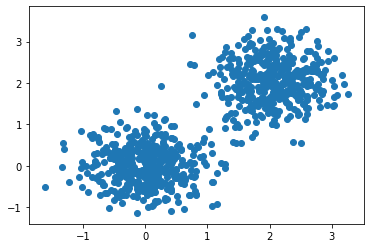

```python
X1 = data_sets[0][0]
plt.scatter(X1[:, 0], X1[:, 1])
```

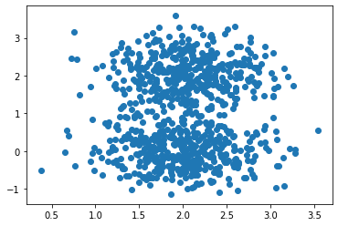

```python
X2 = data_sets[1][0]
plt.scatter(X2[:, 0], X2[:, 1])
```

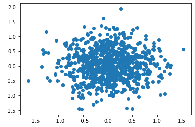

```python
X3 = data_sets[2][0]
plt.scatter(X3[:, 0], X3[:, 1])
```

### Question 2

Given an indentifier for a classifier and features, draw the decision boundary for that classifier after instantiating and then defining it.

You may also find [np.ravel](https://numpy.org/doc/stable/reference/generated/numpy.ravel.html) useful. Read the tutorial for more information on plotting decision boundaries.

You may also find [xlim](https://matplotlib.org/api/_as_gen/matplotlib.pyplot.xlim.html) useful but please make sure you don't hardcode any values; Use your judgement such that all data points are displayed and no point is hidden for any input dataset.

To develop full functionality and pass test cases. You'll have to call the following functions in your code (non-exhaustive). Read relevant documentations.

1. plt.scatter
2. plt.contour
3. np.meshgrid
4. plt.xticks
5. plt.title

```python
def plot_decision_boundary_after_training_clf(X, dataset_id, with_outliers=False,\
    _outliers_fraction=outliers_fraction, rs=42, clf_id=1):

    '''
    args:
        X -> ndarray -> shape (m, 2) => features only (no labels)
        dataset_id -> int -> use for plt.title()
        clf -> int => if 1 use on class SVC else IsolationForest
        with_outliers -> Bool => whether the input data contains manually added outliers.
        outliers_fraction -> float => arg for svm and IsolationForest
        rs -> int => random state for IsolationForest

    return: y_pred -> ndarray -> shape (m,) => which are predicted labels (-1 or 1) of
                                 X using the given classifier. More info in docs.

    Out solution has ~35 lines of code.
    '''
    if clf_id == 1:
        clf = svm.OneClassSVM(nu=_outliers_fraction, kernel="rbf",)
    else:
        clf = IsolationForest(contamination=_outliers_fraction, random_state=rs)

    ### BEGIN SOLUTION
    clf.fit(X)
    y_pred = clf.fit(X).predict(X)

    coordinates_vector1 = np.linspace(-7, 7, 150)
    coordinates_vector2 = np.linspace(-7, 7, 150)
    xx, yy = np.meshgrid(coordinates_vector1, coordinates_vector2)

    Z = clf.predict(np.c_[xx.ravel(), yy.ravel()]) # ravel- flatten the array- 1D
    Z = Z.reshape(xx.shape)
    plt.contour(xx, yy, Z, levels=[0], linewidths=2, colors='black')

    colors = np.array(['black', 'orange'])
    feat1 = X[:, 0]
    feat2 = X[:, 1]
    plt.scatter(feat1, feat2, s=10, color=colors[(y_pred + 1) // 2])
    x_min = feat1.min()
    x_max = feat1.max()
    plt.xlim(x_min-1, x_max+1)
    y_min = feat2.min()
    y_max = feat2.max()
    plt.ylim(y_min-1, y_max+1)
    plt.xticks(())
    plt.yticks(())
    if clf_id == 1:
        if with_outliers:
            plt.title('Decision Boundary for dataset %d (with Outliers) with One Class SVM'% (dataset_id))
        else:
            plt.title('Decision Boundary for dataset %d with One Class SVM'% (dataset_id))
    else:
        if with_outliers:
            plt.title('Decision Boundary for dataset %d (with Outliers) with Random Forest'% (dataset_id))
        else:
            plt.title('Decision Boundary for dataset %d with Random Forest'% (dataset_id))
    return y_pred
    ### END SOLUTION
```

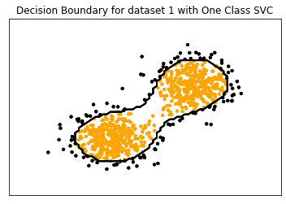

```python
y_pred = plot_decision_boundary_after_training_clf(X1, dataset_id=1)
test_.eq_ (len(y_pred), 850)

### BEGIN HIDDEN TESTS
test_.ok_ ((y_pred[10:30] == np.array(
    [
        1, -1, 1, 1, 1, 1, 1,
        -1, 1,  1,  1, 1, 1, 1,
        1, 1, 1, -1, 1, 1,
    ]
)).all())

# save a reference to the original function, then delete it from the
# global namespace
old_f = plt.scatter
del plt.scatter

# try running the students' code
try:
    plot_decision_boundary_after_training_clf(X1, dataset_id=1)

# if an NameError is thrown, that means their function calls mse
# except NameError:
#     pass

except: # any exception
    pass

# if no error is thrown, that means their function does not call mse
else:
    raise AssertionError("plot_decision_boundary_after_training_clf does \
    not call the required fun1")

# restore the original function
finally:
    plt.scatter = old_f
    del old_f
##############################
old_f = np.meshgrid
del np.meshgrid

# try running the students' code
try:
    plot_decision_boundary_after_training_clf(X1, dataset_id=1)

# if an NameError is thrown, that means their function calls mse
except NameError:
    pass

except: # any exception
    pass

# if no error is thrown, that means their function does not call mse
else:
    raise AssertionError("plot_decision_boundary_after_training_clf does \
    not call the required fun1")

# restore the original function
finally:
    np.meshgrid = old_f
    del old_f
##############################
old_f = plt.title
del plt.title

# try running the students' code
try:
    plot_decision_boundary_after_training_clf(X1, dataset_id=1)

# if an NameError is thrown, that means their function calls mse
except NameError:
    pass

except: # any exception
    pass

# if no error is thrown, that means their function does not call mse
else:
    raise AssertionError("plot_decision_boundary_after_training_clf does \
    not call the required fun1")

# restore the original function
finally:
    plt.title = old_f
    del old_f
# ### END HIDDEN TESTS
```

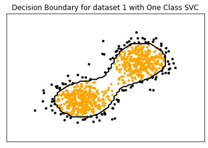

```python
_ = plot_decision_boundary_after_training_clf(X1, dataset_id=1)
```

### `Expected Output`

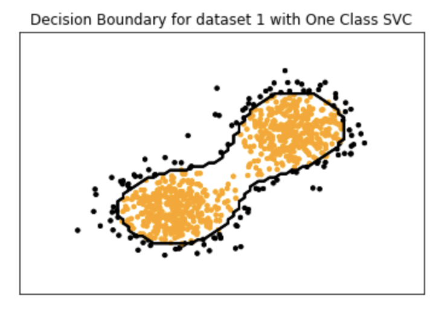

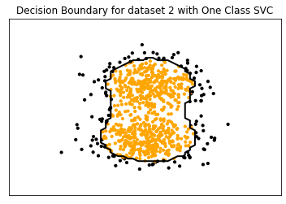

```python
_ = plot_decision_boundary_after_training_clf(X2, dataset_id=2)
```

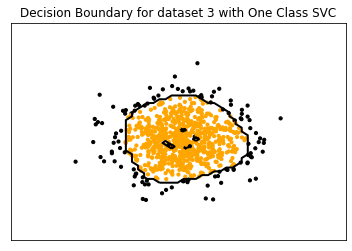

```python
_ = plot_decision_boundary_after_training_clf(X3, dataset_id=3)
```

We argued in the tutorial that oneClassSVM is sensitive to outliers. It works ok if number of outliers in training are not too much. If there many outliers, it'll distort the decision boundary. Let's see if that's the case in our datasets.

### Question 3

Add outliers in all three datasets using [np.random.uniform](https://docs.scipy.org/doc//numpy-1.15.0/reference/generated/numpy.random.uniform.html) given low and high values range within which you'll generate outliers, number of outliers and [random state](https://docs.scipy.org/doc/numpy-1.10.4/reference/generated/numpy.random.RandomState.html) (again, random state is very important for test cases).

```python
def pollute_dataset(datasets_, rs, n_outliers, low_, high_): # add outliers.
    '''
    datasets_ -> list => containing n datasets (X, y)
    rs -> int => random state
    n_outliers -> int => number of outliers to put in each dataset
    low -> int => min possible val of generated outliers. arg for np.random.uniform
    high -> int => max possible val of generated outliers. arg for np.random.uniform

    Other:
        Return labels unchanged.
    '''
    polluted_data_sets = []
    ### BEGIN SOLUTION
    rng = np.random.RandomState(rs)
    for dataset in datasets_:
        X = dataset[0]
        X = np.concatenate([X, rng.uniform(low=low_, high=high_,
                               size=(n_outliers, 2))], axis=0)
        Y = dataset[1] # return as it is
        polluted_data_sets.append((X, Y))
    ### END SOLUTION
    return polluted_data_sets
```

```python
polluted_datasets = pollute_dataset(data_sets, 42, n_outliers,  -5, 4)
test_.ok_ (len(polluted_datasets), 3)
test_.ok_ ((np.isclose (polluted_datasets[0][0][:3], np.asarray(
    [[ 1.50518593,  2.47038559],
     [ 0.03868415, -0.4306421 ],
     [-0.18048308,  0.5796649 ]
    ]))).all())
```

```python
polluted_datasets = pollute_dataset(data_sets, 42, n_outliers, -5, 4)
```

### Question 4

Plot Datasets with Outliers Added.

Make sure you call plt.subplot().

```python
def plot_datasets_with_outliers(polluted_datasets, fig_size=(5,10),):
    ### BEGIN SOLUTION
    plt.figure(figsize=fig_size)
    for idx in range(1, len(polluted_datasets)+1):

        X_polluted = polluted_datasets[0][0]
        plt.subplot(3, 1, idx)
        plt.scatter(X_polluted[:, 0], X_polluted[:, 1])
        plt.title('Dataset %d with outliers'% (idx))
    plt.show()
    ### END SOLUTION
```

```python
# All test cases hidden.
### BEGIN HIDDEN TESTS
old_f = plt.subplot
del plt.subplot

# try running the students' code
try:
    plot_datasets_with_outliers(X1, dataset_id=1)

# if an NameError is thrown, that means their function calls mse
except NameError:
    pass

except: # any exception
    pass

# if no error is thrown, that means their function does not call mse
else:
    raise AssertionError("plot_decision_boundary_after_training_clf does \
    not call the required fun1")

# restore the original function
finally:
    plt.subplot = old_f
    del old_f
# ### END HIDDEN TESTS
```

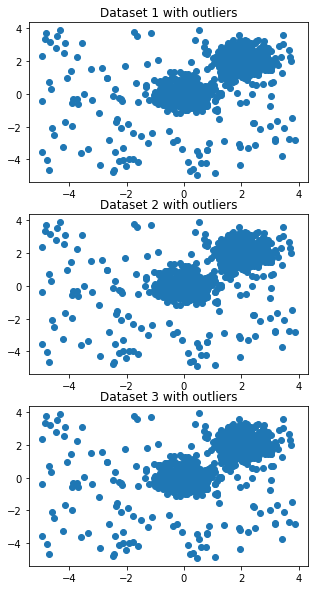

```python
plot_datasets_with_outliers(polluted_datasets)
```

### `Expected Output`

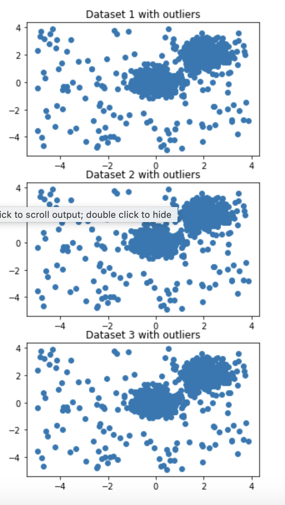

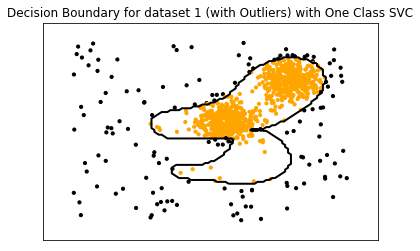

```python
X1_pol = polluted_datasets[0][0]
_ = plot_decision_boundary_after_training_clf(clf_id=1, X=X1_pol, dataset_id=1, \
                                          with_outliers=True)
```

### `Expected Output`

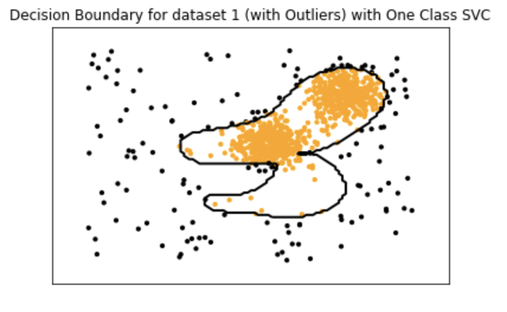

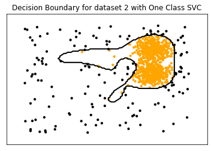

```python
X2_pol = polluted_datasets[1][0]
_ = plot_decision_boundary_after_training_clf(clf_id=1, X=X2_pol, dataset_id=2)
```

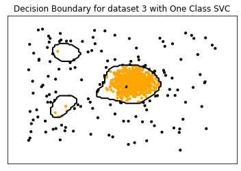

```python
X3_pol = polluted_datasets[2][0]
_ = plot_decision_boundary_after_training_clf(X=X3_pol, clf_id=1, dataset_id=3)
```

- Observe how much distorted are the boundaries because of the outliers. = Also, three separate boundaries. Now, SVM is wrongly covering anamolies inside its decision boundary.

## Isolation Forest

On the other hand, isolation is not so senstitive to outliers.

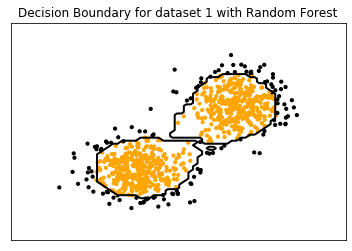

```python
X1 = data_sets[0][0]
_ = plot_decision_boundary_after_training_clf(clf_id=2, X=X1, dataset_id=1)
```

### `Expected Output`

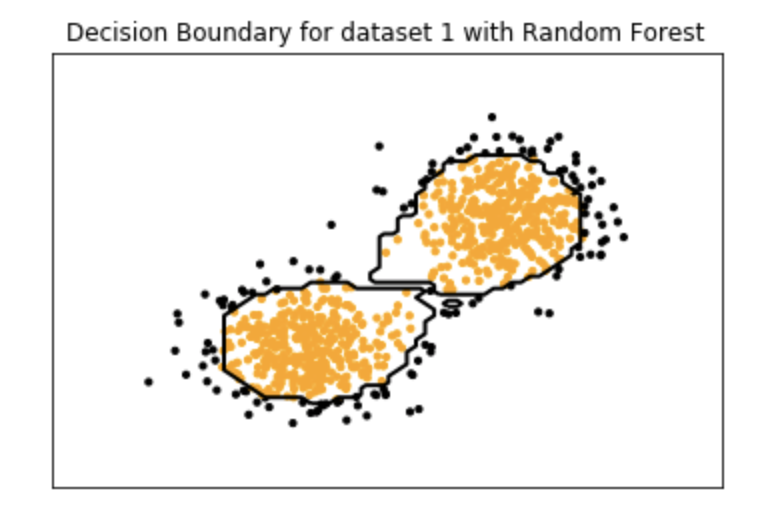

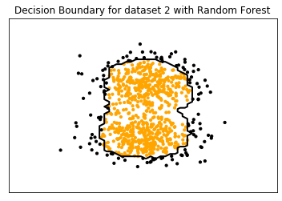

```python
X2 = data_sets[1][0]
_ = plot_decision_boundary_after_training_clf(clf_id=2, X=X2, dataset_id=2)
```

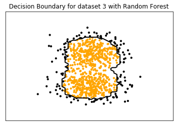

```python
X3 = data_sets[1][0]
_ = plot_decision_boundary_after_training_clf(clf_id=2, X=X3, dataset_id=3)
```

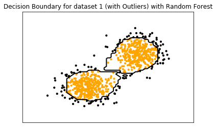

```python
X1_pol = polluted_datasets[0][0]
_ = plot_decision_boundary_after_training_clf(clf_id=2, X=X1, dataset_id=1, with_outliers=True)
```

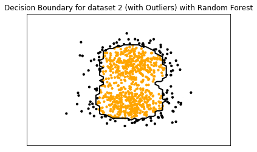

```python
X2_pol = polluted_datasets[1][0]
_ = plot_decision_boundary_after_training_clf(clf_id=2, X=X2, dataset_id=2, with_outliers=True)
```

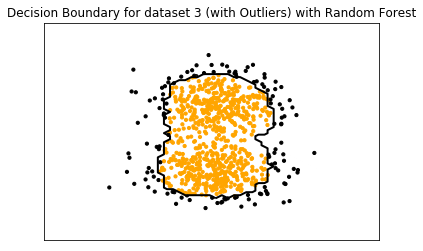

```python
X3_pol = polluted_datasets[2][0]
_ = plot_decision_boundary_after_training_clf(clf_id=2, X=X3, dataset_id=3, with_outliers=True)
```

### `Expected Output`

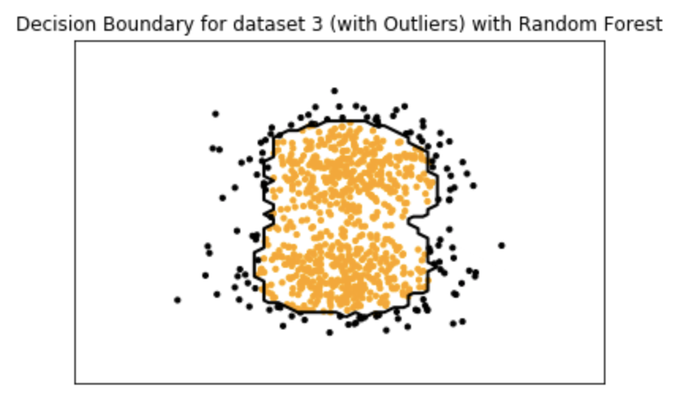